# 10 Modern Extensions

## 10.1 Beyond Quadratic Surrogates

Altus (2002) used quadratic response surfaces as the surrogate model connecting local BB optimizations to the system optimizer. This was a natural choice in 2002: quadratic models are simple to fit, analytically differentiable, and computationally trivial to evaluate. For smooth, unimodal BB responses in low-to-moderate dimensions ($n \leq 15$), they perform well.

Since 2002, the surrogate modelling field has advanced significantly. This chapter surveys four modern extensions to the BLISS-RS framework:

1. **Gaussian Process (Kriging) surrogates** — interpolating surrogates that provide uncertainty estimates alongside predictions.
2. **Bayesian optimization** — an acquisition-function-driven strategy for minimizing expensive BBs with very few evaluations.
3. **Julia’s native parallelism** — using `@distributed` and `@threads` to realize the theoretical parallel speedup of BLISS-RS.
4. **Neural network surrogates** — flexible non-parametric models suitable for highly non-linear BB responses.

## 10.2 Gaussian Process Surrogates (Kriging)

A **Gaussian Process** (GP) is a probabilistic model that treats the unknown function as a random process with a specified mean and covariance (kernel) function [1,2]. Given observations $\{(x_i, y_i)\}_{i=1}^n$, the GP posterior provides both a **mean prediction** $\hat{y}(x)$ and a **predictive variance** $\sigma^2(x)$ at any new input $x$:

$$\hat{y}(x) = k(x, X)(K + \sigma_n^2 I)^{-1} y
\tag{10.1}$$

$$\sigma^2(x) = k(x,x) - k(x, X)(K + \sigma_n^2 I)^{-1} k(X, x)
\tag{10.2}$$

where $K_{ij} = k(x_i, x_j)$ is the kernel matrix, $k(x,x')$ is the covariance function (typically a squared exponential or Matérn kernel), and $\sigma_n^2$ is the observation noise variance (set to a small value for deterministic simulations).

The predictive variance $\sigma^2(x)$ is especially valuable in BLISS-RS: it identifies regions where the surrogate is uncertain, guiding the system optimizer toward either exploiting the current best estimate (low $\sigma$) or exploring uncertain regions (high $\sigma$) — the exploitation/exploration trade-off.

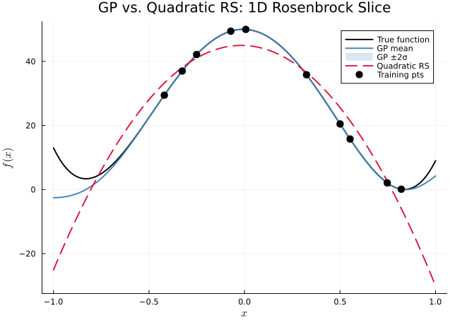

```julia
# Simple GP implementation using squared exponential kernel
function gp_predict(X_train, y_train, x_test;
                     ℓ=0.3, σ_f=1.0, σ_n=1e-6)
    n_train = length(y_train)

    k(a, b) = σ_f^2 * exp(-0.5 * ((a-b)/ℓ)^2)

    # Kernel matrix K
    K = [k(X_train[i], X_train[j]) for i in 1:n_train, j in 1:n_train]
    K += σ_n^2 * I

    # Cross-covariance k*
    k_star = [k(x_test[j], X_train[i]) for j in 1:length(x_test), i in 1:n_train]

    # Posterior mean and variance
    K_inv_y = K \ y_train
    mu      = k_star * K_inv_y

    k_ss = σ_f^2 .* ones(length(x_test))
    var  = k_ss - vec(sum((k_star * (K \ k_star')), dims=2))
    var  = max.(var, 0.0)

    return mu, sqrt.(var)
end

# 1D slice of the 2D Rosenbrock
rosen1d(x) = 100 * (0.7 - x^2)^2 + (x - 1)^2

rng = MersenneTwister(123)
n_train = 10
x_train = sort(2 .* rand(rng, n_train) .- 1)
y_train = rosen1d.(x_train)

x_test = range(-1.0, 1.0, length=200)

# GP prediction
mu_gp, std_gp = gp_predict(x_train, y_train, collect(x_test))

# Quadratic RS prediction
X_rs = hcat(ones(n_train), x_train, x_train.^2)
b_rs = (X_rs' * X_rs) \ (X_rs' * y_train)
X_test_rs = hcat(ones(200), collect(x_test), collect(x_test).^2)
y_rs_pred = X_test_rs * b_rs

# Plot
y_true = rosen1d.(x_test)
p = plot(x_test, y_true, lw=2, color=:black, label="True function",
         xlabel=L"x", ylabel=L"f(x)",
         title="GP vs. Quadratic RS: 1D Rosenbrock Slice",
         legend=:topright)
plot!(x_test, mu_gp, lw=2, color=:steelblue, label="GP mean")
plot!(x_test, mu_gp .- 2*std_gp, fillrange=mu_gp .+ 2*std_gp,
      fillalpha=0.2, color=:steelblue, lw=0, label="GP ±2σ")
plot!(x_test, y_rs_pred, lw=2, color=:crimson, linestyle=:dash,
      label="Quadratic RS")
scatter!(x_train, y_train, color=:black, markersize=6, label="Training pts")
```

### 10.2.1 GP vs. Quadratic RS: Suitability for BLISS-RS

| Property | Quadratic RS | Gaussian Process |
| --- | --- | --- |
| Interpolates training data | No | Yes |
| Provides uncertainty estimate | No | Yes |
| Gradient analytically available | Yes | Yes |
| Scales with $N$ | $O(N)$ fitting | $O(N^3)$ fitting |
| High-dimensional ($n > 20$) | Acceptable | Challenging |
| Non-stationary functions | Poor | Moderate (with ARD kernel) |
| Implementation complexity | Low | Moderate |

For the supersonic business jet problem ($n \leq 14$ per BB, $N_S \leq 120$), GP surrogates are computationally feasible and would likely improve accuracy in later iterations where the RS is evaluated over a small, highly-resolved region.

## 10.3 Bayesian Optimization

**Bayesian optimization** (BO) [3] applies GP surrogates in an active learning loop: after each BB evaluation, the GP is updated and an *acquisition function* selects the next evaluation point. The **Expected Improvement** (EI) acquisition function is:

$$\text{EI}(x) = (f_{\min} - \hat{y}(x))\,\Phi\!\left(\frac{f_{\min} - \hat{y}(x)}{\sigma(x)}\right)
+ \sigma(x)\,\phi\!\left(\frac{f_{\min} - \hat{y}(x)}{\sigma(x)}\right)
\tag{10.3}$$

where $f_{\min}$ is the current best observed function value, $\hat{y}(x)$ is the GP predictive mean, $\sigma(x)$ is the GP predictive standard deviation, and $\Phi$ and $\phi$ are the standard normal CDF and PDF, respectively.

EI balances exploration (high $\sigma$) and exploitation (low $\hat{y}$). In a BLISS-RS context, BO could replace the fixed DOE with an adaptive strategy that concentrates evaluations near the system optimum while maintaining adequate coverage for RS fitting.

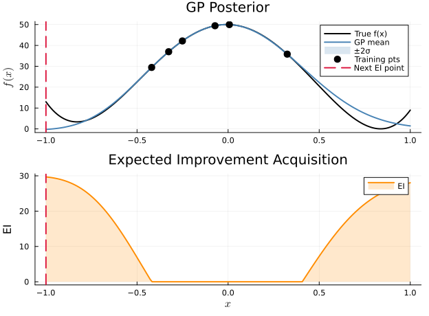

```julia
function expected_improvement(x_test, mu, std, f_min)
    z   = (f_min .- mu) ./ (std .+ 1e-9)
    ei  = (f_min .- mu) .* cdf.(Normal(), z) .+ std .* pdf.(Normal(), z)
    return max.(ei, 0.0)
end

# Use first 6 training points
n_init = 6
x_tr6  = x_train[1:n_init]
y_tr6  = y_train[1:n_init]
f_min  = minimum(y_tr6)

mu6, std6 = gp_predict(x_tr6, y_tr6, collect(x_test))
ei_vals   = expected_improvement(x_test, mu6, std6, f_min)

next_idx = argmax(ei_vals)
x_next   = x_test[next_idx]

p1 = plot(x_test, y_true, lw=2, color=:black, label="True f(x)",
          xlabel="", ylabel=L"f(x)", title="GP Posterior")
plot!(x_test, mu6, lw=2, color=:steelblue, label="GP mean")
plot!(x_test, mu6 .- 2*std6, fillrange=mu6 .+ 2*std6,
      fillalpha=0.2, color=:steelblue, lw=0, label="±2σ")
scatter!(x_tr6, y_tr6, color=:black, markersize=6, label="Training pts")
vline!([x_next], color=:crimson, lw=2, linestyle=:dash, label="Next EI point")

p2 = plot(x_test, ei_vals, lw=2, color=:darkorange, label="EI",
          xlabel=L"x", ylabel="EI",
          title="Expected Improvement Acquisition",
          legend=:topright, fill=(0, 0.2, :darkorange))
vline!([x_next], color=:crimson, lw=2, linestyle=:dash, label="")

plot(p1, p2, layout=(2,1), size=(650, 480))
```

## 10.4 Julia’s Native Parallelism

The theoretical speedup of BLISS-RS over gradient-based methods comes entirely from the ability to run BB optimizations in parallel. Julia provides several parallelism mechanisms that map naturally to the BLISS-RS structure.

### 10.4.1 Multi-Threading (`@threads`)

For BB evaluations on shared memory (multi-core workstation):

```julia
using Base.Threads

function evaluate_bb_parallel(bb_fn, doe_points::Matrix{Float64})
    n_pts = size(doe_points, 1)
    results = Vector{Float64}(undef, n_pts)

    @threads for i in 1:n_pts
        results[i] = bb_fn(doe_points[i, :])
    end
    return results
end
```

### 10.4.2 Distributed Computing (`@distributed`)

For BB evaluations across multiple nodes (HPC cluster):

```julia
using Distributed
addprocs(4)   # add worker processes

@everywhere include("src/supersonic_jet.jl")

function evaluate_bb_distributed(doe_points)
    n_pts = size(doe_points, 1)
    results = @distributed (vcat) for i in 1:n_pts
        Z = doe_points[i, :]
        [ssbj_analysis(Z[1:7], Z[8], Z[9]).Range]
    end
    return results
end
```

### 10.4.3 Speedup Analysis

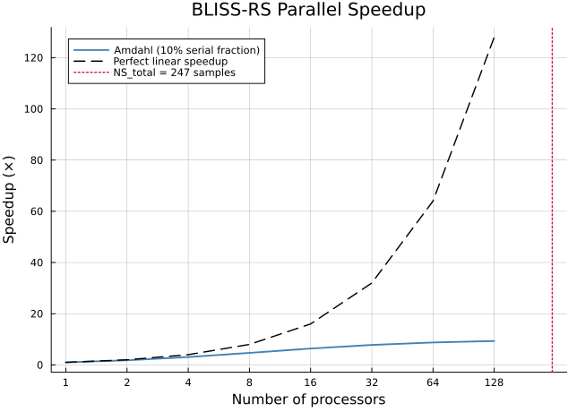

Figure 10.3: Theoretical parallel speedup for BLISS-RS as a function of available processors and BB count. Perfect parallelism over all BBs’ sample points gives near-linear speedup up to min(NS_total, N_procs). The actual speedup is limited by the longest-running BB (Amdahl’s law).

```julia
n_procs = [1, 2, 4, 8, 16, 32, 64, 128]
NS_total = 78 + 120 + 21 + 28   # sum of all BB sample points

# Serial time = NS_total × T_BB (assume equal BB cost)
# Parallel time = ceil(NS_total / n_procs) × T_BB (perfect parallelism)
# Plus Amdahl overhead (10% serial fraction)
serial_frac = 0.10   # interval reduction, RS fitting, system optimizer

speedup(n) = 1.0 / (serial_frac + (1 - serial_frac) / n)

theoretical_speedup = speedup.(n_procs)
limited_speedup     = min.(n_procs, NS_total) ./ 1.0   # limited by sample count

p = plot(n_procs, theoretical_speedup, lw=2, color=:steelblue,
         label="Amdahl (10% serial fraction)",
         xlabel="Number of processors",
         ylabel="Speedup (×)",
         title="BLISS-RS Parallel Speedup",
         xscale=:log2, legend=:topleft, grid=true, gridalpha=0.3,
         xticks=(n_procs, string.(n_procs)))
plot!(n_procs, Float64.(n_procs), lw=1.5, color=:black, linestyle=:dash,
      label="Perfect linear speedup")
vline!([NS_total], color=:crimson, lw=1.5, linestyle=:dot,
       label="NS_total = $NS_total samples")

p
```

## 10.5 Neural Network Surrogates

For highly nonlinear BB responses — common in propulsion and aeroelastic problems — quadratic polynomials and even GPs may be inadequate. Modern deep learning provides flexible function approximators that can represent complex response surfaces given sufficient data.

A simple feedforward network with $L$ hidden layers provides:

$$f_{NN}(x; \theta) = W_L \cdot \sigma(\ldots W_2 \cdot \sigma(W_1 x + b_1) + b_2 \ldots) + b_L
\tag{10.4}$$

In Julia, the `Flux.jl` package provides automatic differentiation and GPU acceleration for neural network training. For BLISS-RS, a neural surrogate could be used in the system optimization phase (replacing the quadratic polynomial evaluation) with gradient information obtained via automatic differentiation.

The trade-off vs. quadratic RS:

| Property | Quadratic RS | Neural Network |
| --- | --- | --- |
| Training cost | Negligible ($O(N^3)$ solve) | Moderate (iterative gradient descent) |
| Evaluation cost | Negligible | Moderate |
| Gradient availability | Analytical | Via autograd (Flux.jl) |
| Data requirements | $N_S = O(n^2)$ | $N_S = O(n^3)$ or more |
| Extrapolation | Smooth polynomial | Can oscillate |

Neural surrogates become advantageous when $n > 20$ and the BB response has strong non-linearities that cannot be captured by a quadratic. For the supersonic business jet ($n = 14$ for the aero BB), neural surrogates would provide marginal benefit over GPs at much greater complexity.

## 10.6 Data Reuse Across Iterations

A key inefficiency noted in Altus (2002) is that each BLISS-RS iteration generates a completely new set of DOE points, discarding data from previous iterations. This is conservative: as the interval shrinks, old points outside the new interval are useless, but points inside the new interval still contain valid information.

A modern approach — called **warm starting** or **incremental surrogate updating** — retains points from previous iterations that fall within the current bounds:

$$\mathcal{D}_k = \{(x_i, y_i) \mid x_i \in [L_k, H_k]\} \cup \mathcal{D}_{k-1}^{\text{interior}}
\tag{10.5}$$

## 10.7 Summary of Recommended Modern Upgrades

Table 10.1: Recommended modern upgrades to the BLISS-RS framework

| Area | 2002 Approach | Modern Recommendation |
| --- | --- | --- |
| Surrogate model | Quadratic polynomial | GP (Kriging) for $n \leq 15$; NN for $n > 20$ |
| DOE strategy | D-optimal (fixed) | Bayesian adaptive (EI acquisition) |
| Parallel execution | Conceptual only | Julia `@distributed` on HPC |
| Data management | Fresh DOE each iteration | Warm-start with interior points |
| Gradient computation | Finite differences | ForwardDiff.jl (exact autodiff) |
| Uncertainty quantification | None | GP predictive variance → probabilistic optimum |

[1]

Sacks, J., Welch, W. J., Mitchell, T. J., and Wynn, H. P., “Design and Analysis of Computer Experiments,” *Statistical Science*, Vol. 4, No. 4, 1989, pp. 409–423.

[2]

Krige, D. G., “A Statistical Approach to Some Basic Mine Valuation Problems on the Witwatersrand,” *Journal of the Chemical, Metallurgical and Mining Society of South Africa*, Vol. 52, No. 6, 1951, pp. 119–139.

[3]

Jones, D. R., Schonlau, M., and Welch, W. J., “Efficient Global Optimization of Expensive Black-Box Functions,” *Journal of Global Optimization*, Vol. 13, 1998, pp. 455–492.